# Life-history traits explain variation in the larval dispersal potential of corals

## Systematic review figures

Code to produce figures 1 and 3 and summarise data from the systematic review.

### Packages

Code to load (and install if necessary) the packages needed. (Remove “#”s to install packages.)

```r
#  install.packages("tidyverse")
library(tidyverse)

# install.packages("gridExtra")
library(gridExtra)
```

### Data

Read in the data from the systematic review, and the coral IUCN status data

```r
#Review data
review_data_raw <- read_csv("data/review-data.csv")

#IUCN data
#Taxonomic data for Anthozoan species with status assessments made
iucn_status_raw <- read_csv("data/IUCN_assessments.csv")
#Conservation status data for Anthozoans
iucn_taxa_raw <- read_csv("data/IUCN_taxon.csv")
```

### Data wrangling - methodology data

Create a summary dataframe with a column column categorising the type of study and with collapsing the data to just one row per study

```r
#Add in a study type column
review_sum <- review_data_raw %>%
  mutate(study_type = case_when(  #assign each combination of methods to a category
    pop_genetic == "1" & pop_genomic == "1" & biophys == "1" ~ "genom_model_comb",
    pop_genetic == "1" & pop_genomic == "1" & experimental == "1" ~ "genom_experimental_comb",
   pop_genetic == "1" & biophys == "1" ~ "gene_model_comb",
   experimental == "1" & biophys == "1" ~ "experimental_model_comb",
   pop_genetic == "1" & experimental == "1" ~ "experimental_genetic_comb",
   pop_genomic == "1" ~ "Genomics",
   pop_genetic == "1" ~ "Genetics",
   biophys == "1" ~ "Biophysical modelling",
   lab == "1" & field_recruitment == "1" ~ "lab_field_comb", #group field tracking and recruitment studies together
   lab == "1" & field_tracking == "1" ~ "lab_field_comb",
   field_recruitment == "1" | field_tracking == "1" ~ "Field",
   lab == "1" ~ "Lab",
   .default = NA)  #in case any studies have not been properly categorised (should be no NAs)
  ) %>%
  distinct(acc_id, .keep_all = TRUE) #use only 1 row for studies with more than one species recorded
```

Create another summary dataframe of different methods used each year. Create a custom re-ordering and re-labelling of the methodology categories.

```r
#Create the dataframe
review_time_sum <- review_sum %>%
  subset(select = c(acc_id, study_type, Year)) %>% #select only relevant columns
  group_by(Year, study_type) %>%
  tally() #count the number of studies in each category, each year


#Reorder and re-label study type factors (note that population genomics is included within population genetics)
review_time_sum$study_type <- factor(review_time_sum$study_type, #re-order
                             levels = c("experimental_genetic_comb", "genom_experimental_comb", "Field", "lab_field_comb", "Lab", "experimental_model_comb", "Biophysical modelling", "gene_model_comb", "genom_model_comb", "Genetics", "Genomics"),
                             labels = c("Experimental & population genetics", "Experimental & population genetics", "Experimental", "Experimental", "Experimental", "Experimental & biophysical modelling", "Biophysical modelling", "Population genetics & biophysical modelling", "Population genetics & biophysical modelling", "Population genetics", "Population genetics")) #re-label
```

Make a dataframe summarising the total number of papers using each methodology, with categories for combinations of different methods

```r
#Create the dataframe
method_totals <- review_sum %>%
  subset(select = c(acc_id, study_type, Year)) %>%
  distinct(acc_id, .keep_all = TRUE) %>%
  group_by(study_type) %>%
  tally()

#Reorder and re-label study type factors as before (note the labeling differs slightly here)
method_totals$study_type <- factor(method_totals$study_type,
                             levels = c("experimental_genetic_comb", "genom_experimental_comb", "Field", "lab_field_comb", "Lab", "experimental_model_comb", "Biophysical modelling", "gene_model_comb", "genom_model_comb", "Genetics", "Genomics"),
                             labels = c("Experimental & population genetics", "Experimental & population genomics", "Field only", "Lab & Field", "Lab only", "Experimental & Biophysical modelling", "Biophysical modelling only", "Population genetics & biophysical modelling", "Population genomics & biophysical modelling", "Population genetics only", "Population genomics only"))
```

Calculate the numbers of studies in each broader methodological category (note that this will add up to >653 as this doesn’t differentiate studies using multiple method types)

```r
print(paste("Experimental studies, n= ", sum(review_sum$experimental)))
```

```
## [1] "Experimental studies, n=  311"
```

```r
print(paste("Biophysical modelling studies, n= ", sum(review_sum$biophys)))
```

```
## [1] "Biophysical modelling studies, n=  184"
```

```r
print(paste("Experimental studies, n= ", sum(review_sum$pop_genetic)))
```

```
## [1] "Experimental studies, n=  237"
```

### Data wrangling - species data

Calculate the unique accepted species count, and break down by stony vs soft corals

```r
#Create dataframe for species meta-data
species_meta <- review_data_raw %>%
  filter(!is.na(species_accepted)) %>% #filter out invalid species entries (i.e. studies with non-specific "unidentified", "various", or "generic" corals)
  distinct(species_accepted, .keep_all = TRUE) %>% # 1 row per valid species
  subset(select = c(species_accepted, genus_accepted, family_accepted, order_accepted, class_accepted)) #remove unnecessary columns

#Counts for stony vs soft corals
#Stony
print(paste("Stony coral species, n=",length(filter(species_meta, order_accepted == "Scleractinia")$species_accepted)))
```

```
## [1] "Stony coral species, n= 158"
```

```r
#Soft (i.e. non-scleractinian)
print(paste("Soft coral species, n=",length(filter(species_meta, order_accepted != "Scleractinia")$species_accepted)))
```

```
## [1] "Soft coral species, n= 63"
```

Count the genera

```r
#Create dataframe for species meta-data
genus_meta <- review_data_raw %>%
  filter(!is.na(genus_accepted)) %>% #filter out invalid genus entries (i.e. corals that are  non-specific "unidentified", "various", or "generic" at the genus-level)
  distinct(genus_accepted, .keep_all = TRUE) %>% # 1 row per valid species
  subset(select = c(genus_accepted, family_accepted, order_accepted, class_accepted)) #remove unnecessary columns

#Counts for stony vs soft corals
#Stony
print(paste("Stony coral genera, n=",length(filter(genus_meta, order_accepted == "Scleractinia")$genus_accepted)))
```

```
## [1] "Stony coral genera, n= 69"
```

```r
#Soft (i.e. non-scleractinian)
print(paste("Soft coral genera, n=",length(filter(genus_meta, order_accepted != "Scleractinia")$genus_accepted)))
```

```
## [1] "Soft coral genera, n= 46"
```

Subset Anthozoan IUCN status data to only species we considered corals in this study

```r
# Filter out anemones from the taxonomic data
iucn_included <- iucn_taxa_raw %>%
  filter(orderName != "ACTINIARIA") %>% # true anemones
  filter(orderName != "PENICILLARIA") %>% #suborder within Ceriantharia (tube-dwelling anemones) used in the order column
  subset(select = c(scientificName, genusName))  # keep the only species and genus name columns
```

Add conservation status to coral species data, noting whether larval dispersal has been studied in each assessed species (or whether it has been studied in another species of the same genus).

```r
iucn_coral_status <- iucn_status_raw %>%
  filter(scientificName %in% iucn_included$scientificName) %>%
  left_join(x = ., y = iucn_included, by = join_by(scientificName)) %>%
  mutate(species_larvae_studied = case_when(
    scientificName %in% review_data_raw$species_accepted ~ "Yes",
    .default = "No"
  ))  %>%
  mutate(genus_larvae_studied = case_when(
    genusName %in% review_data_raw$genus_accepted ~ "Yes",
    .default = "No"
  ))
```

Summarise the counts for each conservation category and status of larval dispersal being studied

```r
#Group data by species
species_conservation_data <- iucn_coral_status %>%
  group_by(redlistCategory, species_larvae_studied) %>%
  tally()

#Group data by genus
genus_conservation_data <- iucn_coral_status %>%
  group_by(redlistCategory, genus_larvae_studied) %>%
  tally()
```

### Data wrangling - biophysical model parameter justifications

Make a dataframe to summarise numbers of modelling studies with different larval duration parameter justifications

Filter for modelling studies, and summarise the parameter justification data.

```r
biophys_meta <- review_data_raw %>%
  filter(biophys == 1) %>% # select modelling studies
  distinct(acc_id, .keep_all = TRUE) %>% # one row per study
  mutate_at(c("just_coral_specific", "just_repro_mode_specific",    "just_order_specific",  "just_family_specific", "just_genus_specific",  "just_species_specific",    "CnB2010",  "n_empirical_cite"), as.numeric) # Make the justification specificity columns numeric
```

Summary of the number of studies in each larval duration parameter justification category.

```r
#Create summary dataframe
just_catsum <- biophys_meta %>%
  group_by(pld_justcat) %>%
  tally()

#Find total number of models using a single parameter for larval duration (i.e. excluding models with a range of larval duration parameters or with no larval duration parameters) (should be 137)
#Filter to only the models we are interested in for this
biophys_singleparam <- biophys_meta %>%
  filter(pld_justcat != "range")
#Print number of models
print(paste("Studies with single larval parameters used, n=",length(biophys_singleparam$acc_id)))
```

```
## [1] "Studies with single larval parameters used, n= 137"
```

Total models citing Connolly and Baird (2010) (this was by far the most prevalent source cited) to justify larval parameter, and total where this is the only source cited.

```r
#Models citing the study
print(paste("Biophysical modelling studies citing Connolly and Baird (2010) to justify larval parameter used, n=",length(filter(biophys_meta, CnB2010 == "1")$acc_id)))
```

```
## [1] "Biophysical modelling studies citing Connolly and Baird (2010) to justify larval parameter used, n= 42"
```

```r
#Models where this is the only source cited
print(paste("Biophysical modelling studies where Connolly and Baird (2010) is the only source cited to justify larval parameter used, n=",length(filter(biophys_meta, CnB2010 == "1" & n_empirical_cite == 1)$acc_id)))
```

```
## [1] "Biophysical modelling studies where Connolly and Baird (2010) is the only source cited to justify larval parameter used, n= 27"
```

Calculate proportions of models citing data at different levels of specificity, and break down by proportion calculated from the overall total vs from the total minus generic corals at each level.

```r
just_specificity_sum <- biophys_singleparam %>%
  summarise(prop_coralspec = ( sum(just_coral_specific, na.rm = TRUE) /137 ) * 100,
            prop_reprospec = ( sum(just_repro_mode_specific, na.rm = TRUE) /137 ) * 100,
            prop_orderspec = ( sum(just_order_specific, na.rm = TRUE) /137 ) * 100,
            prop_familyspec = ( sum(just_family_specific, na.rm = TRUE) /137 ) * 100,
            prop_genusspec = ( sum(just_genus_specific, na.rm = TRUE) /137 ) * 100,
            prop_speciesspec = ( sum(just_species_specific, na.rm = TRUE) /137 ) * 100,
            G_prop_gencoral = ( sum(is.na(just_coral_specific)) /137 ) * 100,
            G_prop_genrepro = ( sum(is.na(just_repro_mode_specific)) /137 ) * 100,
            G_prop_genorder = ( sum(is.na(just_order_specific)) /137 ) * 100,
            G_prop_genfamily = ( sum(is.na(just_family_specific)) /137 ) * 100,
            G_prop_gengenus = ( sum(is.na(just_genus_specific)) /137 ) * 100,
            G_prop_genspecies = ( sum(is.na(just_species_specific)) /137 ) * 100,
            speccoral_dataprop = ( sum(just_coral_specific, na.rm = TRUE) / (137 - sum(is.na(just_coral_specific)) ) ) * 100,
            specrepro_dataprop = ( sum(just_repro_mode_specific, na.rm = TRUE) / (137 - sum(is.na(just_repro_mode_specific)) ) ) * 100,
            specorder_dataprop = ( sum(just_order_specific, na.rm = TRUE) / (137 - sum(is.na(just_order_specific)) ) ) * 100,
            specfamily_dataprop = ( sum(just_family_specific, na.rm = TRUE) / (137 - sum(is.na(just_family_specific)) ) ) * 100,
            specgenus_dataprop = ( sum(just_genus_specific, na.rm = TRUE) / (137 - sum(is.na(just_genus_specific)) ) ) * 100,
            specspecies_dataprop = ( sum(just_species_specific, na.rm = TRUE) / (137 - sum(is.na(just_species_specific)) ) ) * 100,
 ) %>%
  pivot_longer(cols = everything(),
               names_to = "level",
               values_to = "proportion") %>%
   mutate(generic_code = case_when(
    grepl("G_", level) ~ "2",
    grepl("_dataprop", level) ~ "3",
    .default = "1"
  )) %>%
  mutate(generic = case_when(
    generic_code == 2 ~ "proportion of generic corals for this level",
    generic_code == 3 ~ "from total excluding generic corals for this level",
    .default = "from total including generic corals"
  )) %>%
  mutate(sumlevel = case_when(
    grepl("coral", level) ~ "coral",
    grepl("repro", level) ~ "reproductive-mode",
    grepl("order", level) ~ "order",
    grepl("family", level) ~ "family",
    grepl("genus", level) ~ "genus",
    grepl("species", level) ~ "species"
    ))
```

Count how many models each level for do not model a generic coral

```r
print(paste("Coral specific, n=",137 - sum(is.na(biophys_singleparam$just_coral_specific))))
```

```
## [1] "Coral specific, n= 137"
```

```r
print(paste("Reproductive mode specific, n=",137 - sum(is.na(biophys_singleparam$just_repro_mode_specific))))
```

```
## [1] "Reproductive mode specific, n= 131"
```

```r
print(paste("Order specific, n=",137 - sum(is.na(biophys_singleparam$just_order_specific))))
```

```
## [1] "Order specific, n= 123"
```

```r
print(paste("Family specific, n=",137 - sum(is.na(biophys_singleparam$just_family_specific))))
```

```
## [1] "Family specific, n= 102"
```

```r
print(paste("Genus specific, n=",137 - sum(is.na(biophys_singleparam$just_genus_specific))))
```

```
## [1] "Genus specific, n= 101"
```

```r
print(paste("Species specific, n=",137 - sum(is.na(biophys_singleparam$just_species_specific))))
```

```
## [1] "Species specific, n= 88"
```

Split up summary data versions with and without generic corals included in the totals used to calculate proportions

```r
biophys_just_sum_excl <- just_specificity_sum %>%
  filter(generic_code == "3")

biophys_just_sum_incl <- just_specificity_sum %>%
  filter(generic_code != "3")
```

### Figure 1a

Produce a stacked barplot of coral larval dispersal studies over time, broken down by methodology.

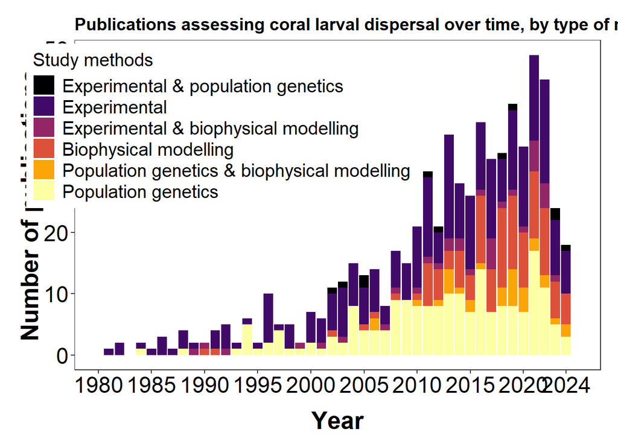

```r
#Stacked barplot of studies over time
fig1a <- ggplot(review_time_sum, aes(x = Year, y = n, fill = study_type)) + # plot count against year, colour bars by method
  geom_bar(position = "stack", stat = "identity") +  # stack bars to break down by methodology
  theme_bw() +
  scale_x_continuous(limits = c(1980, 2025), breaks = c(1980, 1985, 1990, 1995, 2000, 2005, 2010, 2015, 2020, 2024)) + # manually set x axis scale
  scale_fill_viridis_d(option = "B", name = "Study methods") + # use an accessible colour pallette
  theme(panel.grid = element_blank(), # manually set theme for the plot
        plot.margin = unit(c(0.5,0.5,0.5,0.5), units = , "cm"),
        plot.title = element_text(size = 14, face = "bold"),
        axis.text = element_text(size = 18, colour = "black"),
        axis.title = element_text(face = "bold", size = 14),
        axis.title.x = element_text(size = 20, vjust = -1),
        axis.title.y = element_text(size = 20, vjust = 0.5),
        legend.title = element_text(size = 15),
        legend.text = element_text(size = 15),
        legend.position = "inside",
        legend.position.inside = c(0.28, 0.74),
        legend.key.width = unit(0.65, "cm")) +
  labs(x = "Year",
       y = "Number of publications",
       title = "Publications assessing coral larval dispersal over time, by type of methodology used") # label axes and title

#View plot
fig1a
```

```r
#Save plot
ggsave("figures/1a.png", width = 10, height = 5)
```

### Figure 1b & 1c

Produce a species-level plot showing how many species of each conservation status have had larval dispersal studied.

Re-label, re-order, and colour the factors shown in the plot

```r
#Label study inclusion for plot
species_conservation_data$species_larvae_studied <- factor(species_conservation_data$species_larvae_studied,
                             levels = c("No", "Yes"),
                             labels = c("No", "Yes"))


#Reorder conservation status factors
species_conservation_data$redlistCategory <- factor(species_conservation_data$redlistCategory,
                             levels = c("Data Deficient", "Least Concern", "Near Threatened", "Vulnerable", "Endangered", "Critically Endangered"),
                             labels = c("Data \nDeficient", "Least \nConcern", "Near \nThreatened", "Vulnerable", "Endangered", "Critically \nEndangered"))


# Use the official IUCN colour pallette for each conservation status
cons_status_palette <- c( "#D1D1C6", "#60C659", "#CCE226", "#F9E814", "#FC7F3F", "#D81E05")
names(cons_status_palette) <- levels(species_conservation_data$redlistCategory)


#Create a colour palette to shade the plot according to whether larval dispersal has been studied in species
species_larval_status_palette <- c(0.25, 1)
names(species_larval_status_palette) <- levels(species_conservation_data$species_larvae_studied)
```

Produce a stacked barplot displaying the total species with/without larval dispersal studied in each conservation status category.

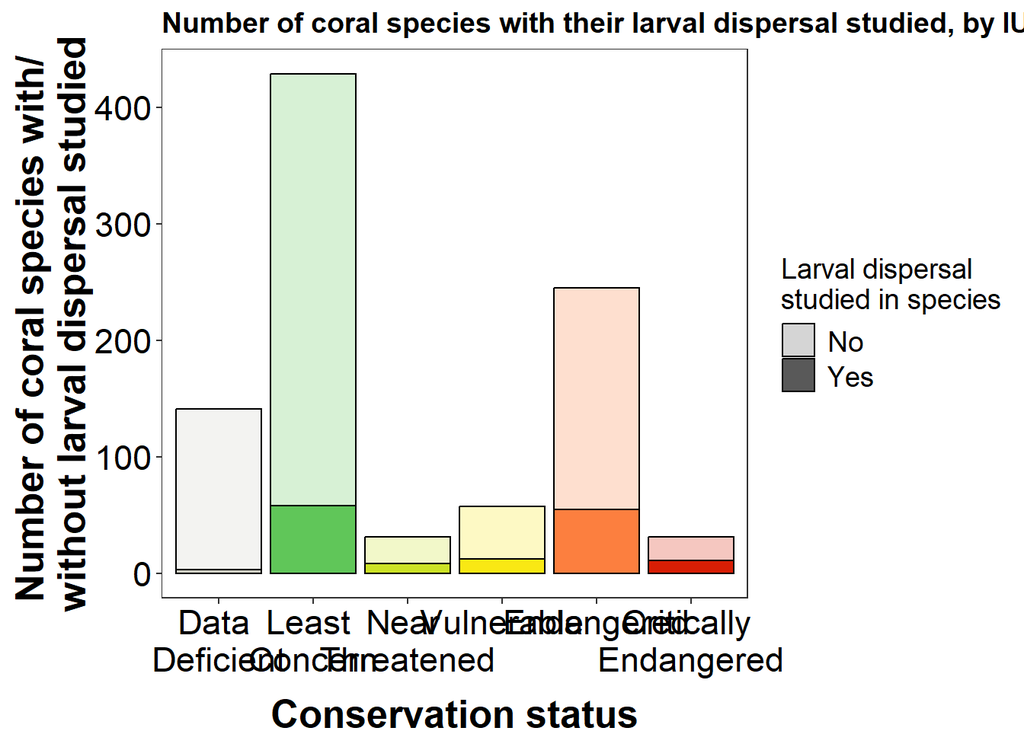

```r
# Create plot
fig1b <- ggplot(species_conservation_data, aes(x = redlistCategory, y = n, alpha = species_larvae_studied, fill = redlistCategory)) + # Plot count against conservation status, broken down by larval dispersal studied
  geom_bar(position = "stack", stat = "identity", colour = "black") + # Stack bars
  scale_alpha_manual(values = species_larval_status_palette,
                      name = "Larval dispersal \nstudied in species") + # Shade bars by larval dispersal studied
  scale_fill_manual(values = cons_status_palette,
                      name = NA) + # Colour bars by conservation status
  theme_bw() + # Manually set theme
  theme(panel.grid = element_blank(),
        plot.title = element_text(size = 14, face = "bold"),
        axis.text.x =  element_text(size = 17, colour = "black"),
        axis.text.y =  element_text(size = 17, colour = "black"),
        axis.title.x =  element_text(size = 19, face = "bold", vjust = -1),
        axis.title.y = element_text(size = 19, face = "bold", vjust = 0.57, hjust = 0.5),
        legend.title = element_text(size = 14),
        legend.text = element_text(size = 14)) +
  guides(fill = "none") +
  labs(x =  "Conservation status",
       y = "Number of coral species with/ \nwithout larval dispersal studied",
       title = "Number of coral species with their larval dispersal studied, by IUCN status") # Label axes/title

#View figure
fig1b
```

```r
#Save figure
ggsave("figures/1b.png", width = 10, height = 5)
```

Repeat re- labeling, re-ordering, and shading for genus-level data.

```r
#Reorder conservation status factors
genus_conservation_data$redlistCategory <- factor(genus_conservation_data$redlistCategory,
                             levels = c("Data Deficient", "Least Concern", "Near Threatened", "Vulnerable", "Endangered", "Critically Endangered"),
                             labels = c("Data \nDeficient", "Least \nConcern", "Near \nThreatened", "Vulnerable", "Endangered", "Critically \nEndangered"))

#Label study inclusion for plot
genus_conservation_data$genus_larvae_studied <- factor(genus_conservation_data$genus_larvae_studied,
                             levels = c("No", "Yes"),
                             labels = c("No", "Yes"))

#Create a colour palette
larval_status_palette <- c(0.25, 1)
names(larval_status_palette) <- levels(genus_conservation_data$genus_larvae_studied)
```

Produce a stacked barplot displaying the total species with/without larval dispersal studied in its genus, for each conservation status category.

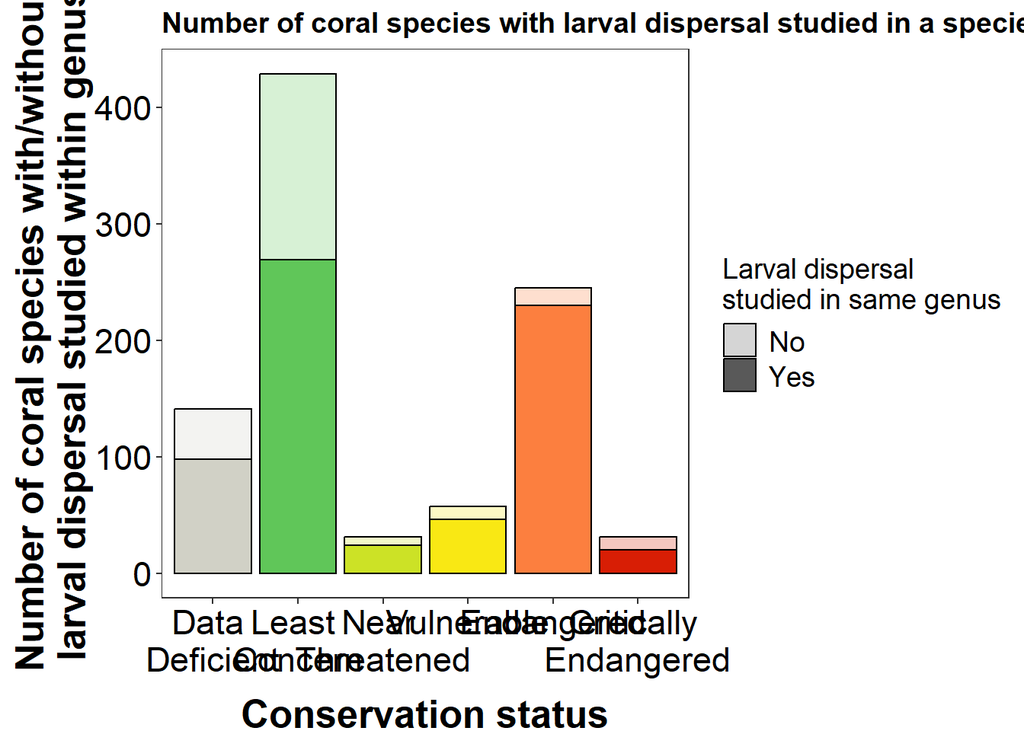

```r
#Create plot
fig1c <- ggplot(genus_conservation_data, aes(x = redlistCategory, y = n, alpha = genus_larvae_studied, fill = redlistCategory)) + # Plot count against conservation status, broken down by larval dispersal studied
  geom_bar(position = "stack", stat = "identity", colour = "black") + # Stack bars
  scale_alpha_manual(values = larval_status_palette,
                      name = "Larval dispersal \nstudied in same genus") + # Shade bars by larval dispersal studied
  scale_fill_manual(values = cons_status_palette,
                      name = NA) + # Colour bars by conservation status
  theme_bw() + # Manually set theme
  theme(panel.grid = element_blank(),
        plot.title = element_text(size = 14, face = "bold"),
        axis.text.x =  element_text(size = 17, colour = "black"),
        axis.text.y =  element_text(size = 17, colour = "black"),
        axis.title.x =  element_text(size = 19, face = "bold", vjust = -1),
        axis.title.y = element_text(size = 19, face = "bold", vjust = 0.57, hjust = 0.5),
        legend.title = element_text(size = 14),
        legend.text = element_text(size = 14)) +
  guides(fill = "none") +
  labs(x =  "Conservation status",
       y = "Number of coral species with/without \nlarval dispersal studied within genus",
       title = "Number of coral species with larval dispersal studied in a species of the same genus") # Label axes/title

# View figure
fig1c
```

```r
# Save figure
ggsave("figures/1c.png", width = 10, height = 5)
```

### Figure 1 panel

Produce a panel for figure 1, combining 1a, 1b, & 1c.

[figure not shown]

```r
fig1_panel <- grid.arrange(fig1a +
                             ggtitle("(a)") +
                             theme(legend.position = "inside",
                                   legend.position.inside = c(0.275, 0.75),
                                   legend.title = element_text(face = "bold")),
                           fig1b +
                             ggtitle("(b)") +
                             theme(legend.position = c(0.85, 0.85),
                                   legend.title = element_text(face = "bold", size = 15),
                                   legend.text = element_text(size = 14)),
                           fig1c +
                             ggtitle("(c)") +
                             theme(legend.position = c(0.85, 0.85),
                                   legend.title = element_text(face = "bold", size = 15),
                                   legend.text = element_text(size = 14)))
```

```r
fig1_panel
```

```r
ggsave(fig1_panel, file = "figures/fig1_panel.png", width = 10, height = 16)
```

### Figure 3

Produce a bar plot showing the level of specificity of data used to parameterise larval duration in biophysical modelling studies

First, reorder and relabel factors for the plot

```r
#Level of organisation
biophys_just_sum_excl$sumlevel <- factor(biophys_just_sum_excl$sumlevel,
                             levels = c("coral", "reproductive-mode", "order", "family", "genus", "species"),
                             labels = c("Any empirical coral\nlarval data used", "Same reproductive\nmode", "Same Order", "Same family", "Same genus", "Same species"))
```

Produce the barplot

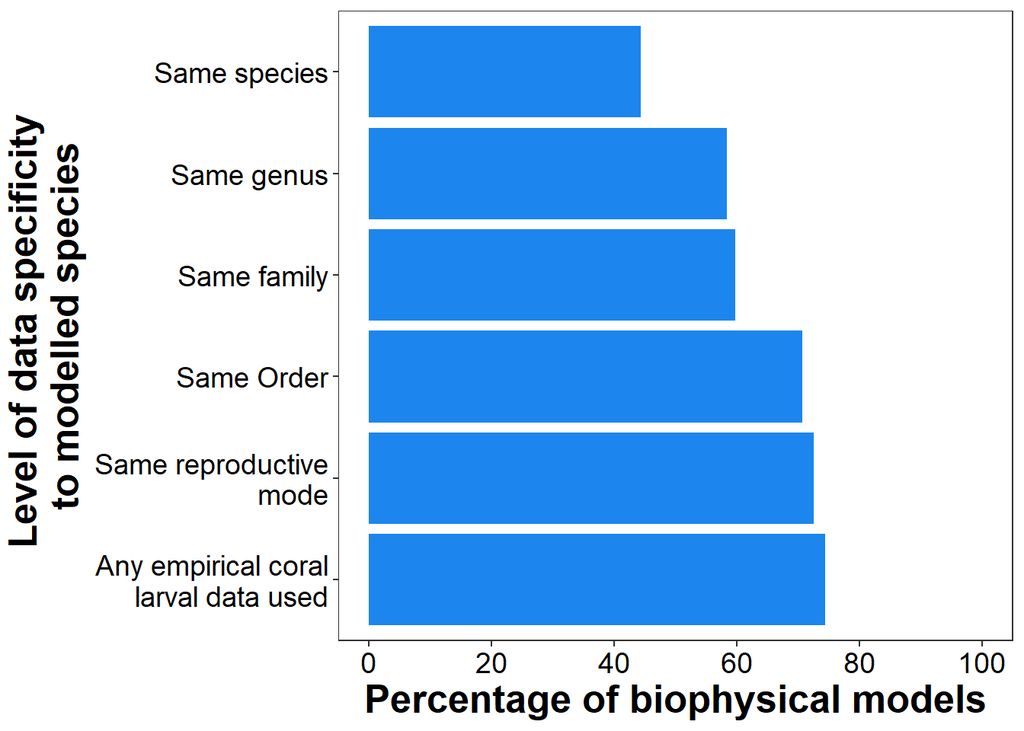

```r
#Create figure
fig3 <- ggplot(biophys_just_sum_excl, aes(y = sumlevel, x = proportion)) + # Plot level of specificity against proportion of model parameters
  geom_bar(position = "stack", stat = "identity", fill = "dodgerblue2") +
  theme_bw() +
  scale_x_continuous(limits = c(0, 100), breaks = c(0, 20, 40, 60, 80, 100)) + # Specify x axis scale
  theme(panel.grid = element_blank(),
        axis.text = element_text(size = 14, colour = "black"),
        axis.title = element_text(face = "bold", size = 19),
        axis.title.y = element_text(vjust = 1.5)
        ) + # Manually set theme
  labs(y = "Level of data specificity \nto modelled species",
       x = "Percentage of biophysical models") # Label axes

#View plot
fig3
```

```r
#Save plot
ggsave("figures/fig3.png", width = 12, height = 5)
```